# Projekt z analizy danych

Bartłomiej Smolski

27-11-2021

# Wczytanie bibliotek

```r
library(dplyr, warn.conflicts = FALSE)
library(tidyr, warn.conflicts = FALSE)
library(ggplot2, warn.conflicts = FALSE)
library(readxl, warn.conflicts = FALSE)
library(plotly, warn.conflicts = FALSE)
```

# Zapewnienie powtarzalności

```r
set.seed(997)
```

# Wczytanie danych

```r
bitcoin_diff <- read.csv("data/Bitcoin/BCHAIN-DIFF.csv", header=TRUE)
bitcoin_diff[,1] <- as.POSIXct(strptime(bitcoin_diff[,1], "%Y-%m-%d"))

bitcoin_hrate <- read.csv("data/Bitcoin/BCHAIN-HRATE.csv", header=TRUE)
bitcoin_hrate[,1] <- as.POSIXct(strptime(bitcoin_hrate[,1], "%Y-%m-%d"))

bitcoin_mkpru <- read.csv("data/Bitcoin/BCHAIN-MKPRU.csv", header=TRUE)
bitcoin_mkpru[,1] <- as.POSIXct(strptime(bitcoin_mkpru[,1], "%Y-%m-%d"))

bitcoin_trvou <- read.csv("data/Bitcoin/BCHAIN-TRVOU.csv", header=TRUE)
bitcoin_trvou[,1] <- as.POSIXct(strptime(bitcoin_trvou[,1], "%Y-%m-%d"))

currency_exchange_rates <- read.csv("data/CurrencyExchangeRates.csv", header=TRUE)
currency_exchange_rates[,1] <- as.POSIXct(strptime(currency_exchange_rates[,1], "%Y-%m-%d"))

gold_prices <- read.csv("data/Gold_prices.csv", header=TRUE, col.names = c("date", "USD_AM", "USD_PM", "GBP_AM",  "GBP_PM",  "EURO_AM", "EURO_PM"))
gold_prices[,1]  <- as.POSIXct(strptime(gold_prices[,1], "%Y-%m-%d"))

s_p_composite <- read.csv("data/S&PComposite.csv", header=TRUE)
s_p_composite[,1] <- as.POSIXct(strptime(s_p_composite[,1], "%Y-%m-%d"))

world_development_indicators <- read_excel("data/World_Development_Indicators.xlsx", sheet="Data", na=c(".."))
```

# Czyszczenie danych

```r
gold_prices <- mutate(gold_prices,USD=f(USD_AM,  USD_PM), GBP=f(GBP_AM, GBP_PM), EURO=f(EURO_AM, EURO_PM)) %>%
  select(date, USD, GBP, EURO) %>%
  gather(currency, value, USD:EURO) %>%
  mutate(currency=as.factor(currency))  %>%
  filter(!is.na(value))

#gold_prices$currency <- as.factor(gold_prices$currency )
s_p_composite <- gather(s_p_composite, measurment, value, S.P.Composite:Cyclically.Adjusted.PE.Ratio) %>%
  mutate(measurment=as.factor(measurment)) %>%
  filter(!is.na(value))

world_development_indicators <- gather(world_development_indicators,year, value, "1970 [YR1970]":"2020 [YR2020]") %>%
  mutate(year=as.POSIXct(strptime(sprintf('%s-12-31',substr(year, 1, 4)), "%Y-%m-%d"))) %>%
  rename(country_name=`Country Name`, indicator=`Series Name`) %>%
  mutate(country_name=as.factor(country_name), indicator=as.factor(indicator)) %>%
  filter(!is.na(value)) %>%
  select(country_name, indicator, year, value)
```

# Podsumowanie rozmiaru zbioru, podstawowe statystyki i analiza atrybutów

## Bitcoin

### Trudność znalezienia nowego bloku

Statystki

|  | Date | Value |
| --- | --- | --- |
|  | Min. :2009-01-02 00:00:00 | Min. :0.000e+00 |
|  | 1st Qu.:2012-03-11 18:00:00 | 1st Qu.:1.689e+06 |
|  | Median :2015-05-20 12:00:00 | Median :4.881e+10 |
|  | Mean :2015-05-20 12:24:33 | Mean :3.664e+12 |
|  | 3rd Qu.:2018-07-28 06:00:00 | 3rd Qu.:5.364e+12 |
|  | Max. :2021-10-05 00:00:00 | Max. :2.505e+13 |

Zbiór zawiera 4660 obserwacji reprezentujących trudność znalezienia nowego bloku podczas kopania kryptowaluty z okresu między 2009-01-02 a 2021-10-05. Na poniższym wykresie widać, że wartości zaczęły gwałtownie rosnąć od 2017 roku z wyraźniejszymi spadkami w roku 2019 i 2021.

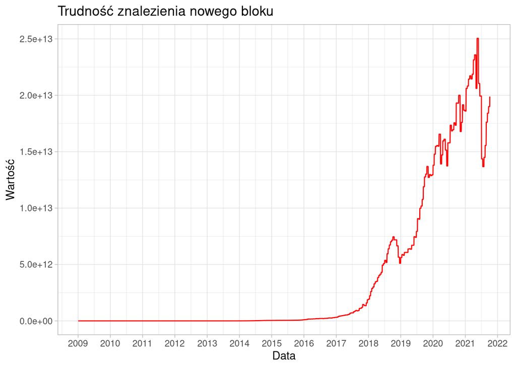

### Szacowana liczba tera haszy na sekundę wykonywanych przez sieć Bitcoina

Statystyki

|  | Date | Value |
| --- | --- | --- |
|  | Min. :2009-01-03 00:00:00 | Min. : 0 |
|  | 1st Qu.:2012-03-12 12:00:00 | 1st Qu.: 12 |
|  | Median :2015-05-21 00:00:00 | Median : 356089 |
|  | Mean :2015-05-21 00:24:32 | Mean : 26458258 |
|  | 3rd Qu.:2018-07-28 12:00:00 | 3rd Qu.: 38265984 |
|  | Max. :2021-10-05 00:00:00 | Max. :198514006 |

Zbiór zawiera 4659 obserwacji przedstawiających liczbę tera haszy na sekundę wykonywanych przez sieć Bitcoina w okresie od 2009-01-03 do 2021-10-05. Na poniższym wykresie widać podobny trend jak w przypadku trudności znalezienia nowego bloku. Potwierdza to współczynnik korelacji Pearsona, który wynosi 0.989704.

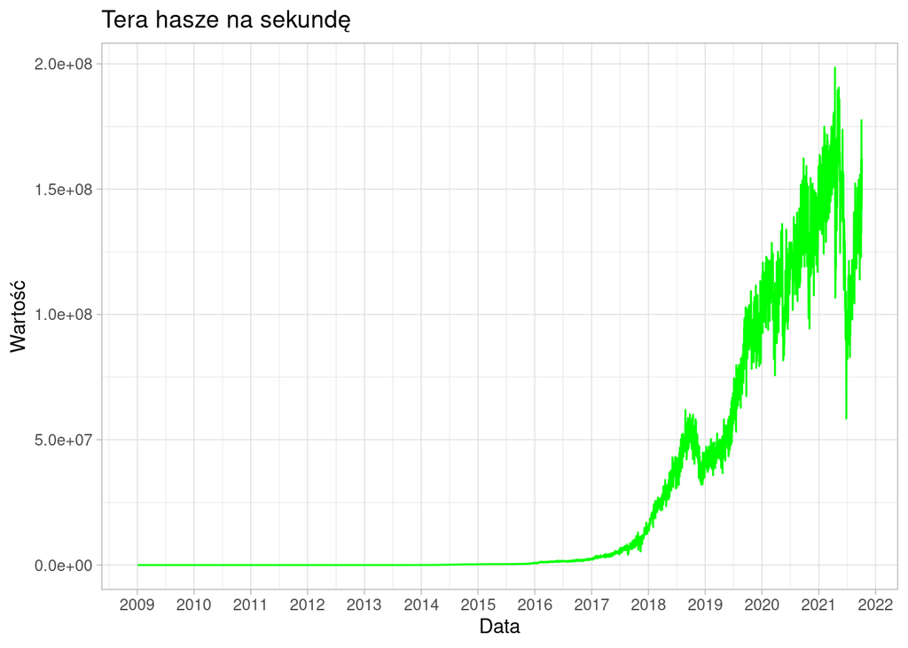

### Średnia wartość w USD

Statystyki

|  | Date | Value |
| --- | --- | --- |
|  | Min. :2009-01-02 00:00:00 | Min. : 0.0 |
|  | 1st Qu.:2012-03-12 00:00:00 | 1st Qu.: 7.2 |
|  | Median :2015-05-21 00:00:00 | Median : 431.9 |
|  | Mean :2015-05-21 00:24:32 | Mean : 5141.2 |
|  | 3rd Qu.:2018-07-29 00:00:00 | 3rd Qu.: 6499.1 |
|  | Max. :2021-10-06 00:00:00 | Max. :63554.4 |

Zbiór zaweierający wartości Bitcoina w dolarach zawiera 4661 obserwacji. W okresie od 2009-01-02 do 2021-10-06 najwyższa warość Bitocina wyniosła 6.355444^{4} dolarów, a średnia 5141.23 dolarów. Duży spadek, który można zaobserwować w połowie 2021 roku spowodowany został zapowiedziami Chińskiego rządu dotyczącymi regulacji odnośnie kryptowalut oraz tweetami Elona Muska na temat zablokowania możliwości płacenia za samochody marki Tesla w tej kryptowalucie czy sprzedaży przez tę firmę sprzedaży posiadanych Bitcoinów o wartości 1,5 mld dolarów (https://pl.wikipedia.org/wiki/Bitcoin#Rynek). Wykres wygląda podobnie do wykresu trudności znaleziania nowego bloku i szacowanej liczby tera haszy na sekunde co potwierdzają wartości współczynnika korelacji Pearsona, które wynoszą odpowiednio 0.82 i 0.82.

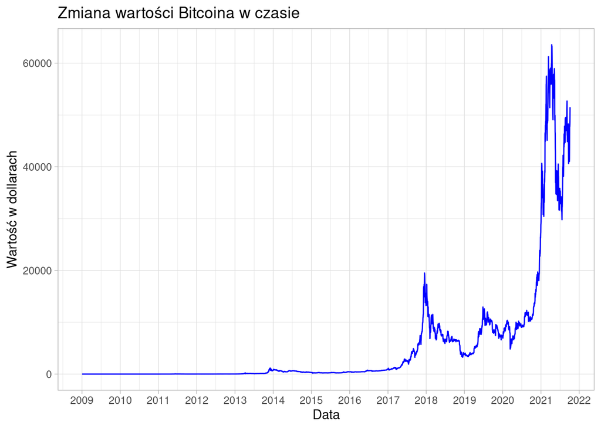

Korelację między trudnością znalezienia nowego bloku, szacowaną liczbą tera haszy na sekundę i wartością Bitcoina w dolarach można pokazać na jednym wykresie. W celu czytelenego pokazania wszystkich zmiennych wartości poszczególnych miar zostały znormalizowane.

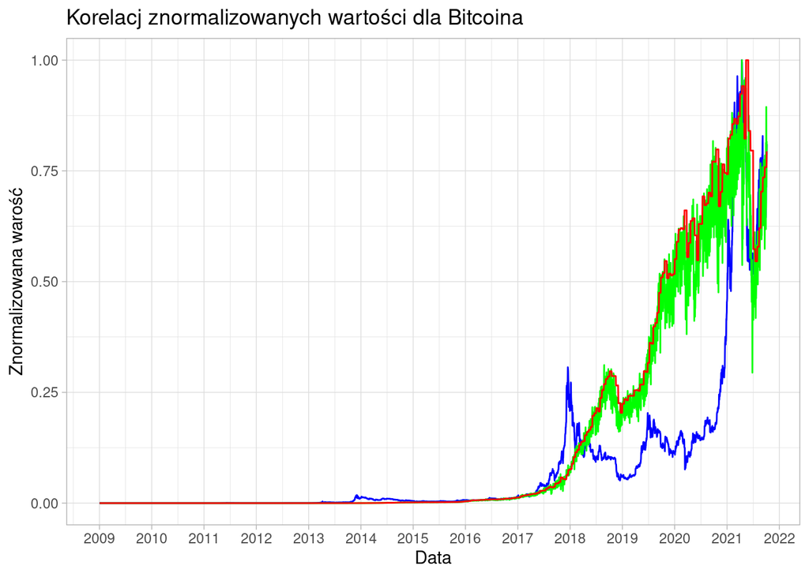

### Wartość w USD wolumenu obrotu

Statystyki

|  | Date | Value |
| --- | --- | --- |
|  | Min. :2009-01-02 00:00:00 | Min. : 0 |
|  | 1st Qu.:2012-03-12 00:00:00 | 1st Qu.: 194787 |
|  | Median :2015-05-21 00:00:00 | Median : 6823690 |
|  | Mean :2015-05-21 00:24:32 | Mean : 146728050 |
|  | 3rd Qu.:2018-07-29 00:00:00 | 3rd Qu.: 148443298 |
|  | Max. :2021-10-06 00:00:00 | Max. :5352015516 |

Zbiór zaweierający wartość obrotu Bitcoina wyrażony w dolarach zawiera 4661 obserwacji. Najwyższy obrót o wartości 5.3520155^{9} USD odnotowano dnia 2017-12-22. Korelacja tej miary z wartością Bitcoina w dolarach wynosi 0.53 a z liczbą tera haszy na sekundę 0.39. Obie te korelacje są małe.

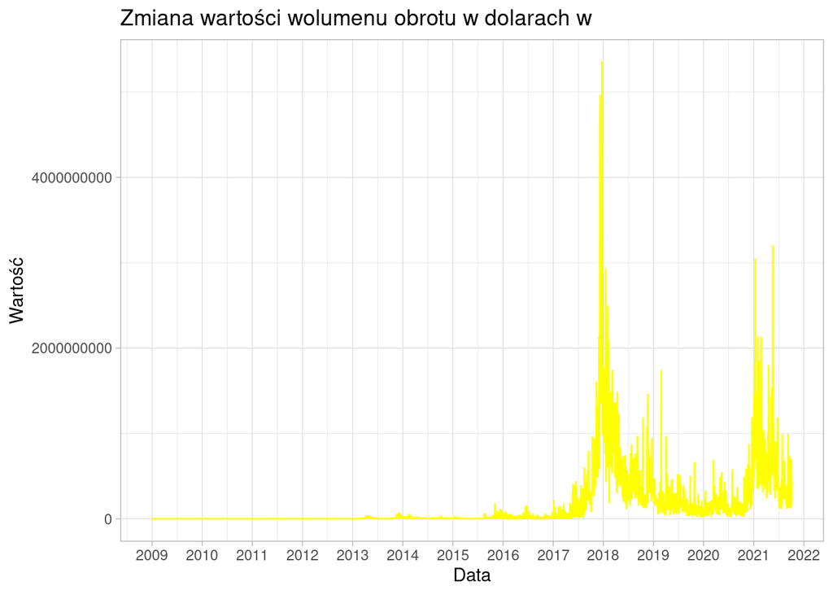

## Cena złota

### EURO

Statystyki

|  | date | currency | value |
| --- | --- | --- | --- |
|  | Min. :1999-01-04 00:00:00 | EURO:5748 | Min. : 237.0 |
|  | 1st Qu.:2004-09-09 18:00:00 | GBP : 0 | 1st Qu.: 335.2 |
|  | Median :2010-05-18 12:00:00 | USD : 0 | Median : 894.7 |
|  | Mean :2010-05-18 00:24:54 | NA | Mean : 797.3 |
|  | 3rd Qu.:2016-01-25 06:00:00 | NA | 3rd Qu.:1114.7 |
|  | Max. :2021-09-29 00:00:00 | NA | Max. :1736.2 |

### Funt brytyjski

Statystyki

|  | date | currency | value |
| --- | --- | --- | --- |
|  | Min. :1968-01-02 00:00:00 | EURO: 0 | Min. : 14.48 |
|  | 1st Qu.:1981-06-22 06:00:00 | GBP :13574 | 1st Qu.: 177.71 |
|  | Median :1994-11-21 12:00:00 | USD : 0 | Median : 234.52 |
|  | Mean :1994-11-23 03:49:44 | NA | Mean : 370.78 |
|  | 3rd Qu.:2008-04-27 06:00:00 | NA | 3rd Qu.: 454.79 |
|  | Max. :2021-09-29 00:00:00 | NA | Max. :1566.94 |

### Dolar amerykański

Statystyki

|  | date | currency | value |
| --- | --- | --- | --- |
|  | Min. :1968-01-02 00:00:00 | EURO: 0 | Min. : 34.76 |
|  | 1st Qu.:1981-06-10 00:00:00 | GBP : 0 | 1st Qu.: 280.27 |
|  | Median :1994-11-14 00:00:00 | USD :13585 | Median : 383.38 |
|  | Mean :1994-11-16 03:40:00 | NA | Mean : 575.07 |
|  | 3rd Qu.:2008-04-23 00:00:00 | NA | 3rd Qu.: 841.00 |
|  | Max. :2021-09-29 00:00:00 | NA | Max. :2058.15 |

## Wyniki S&P Composite

Statystyki

|  | Year | measurment | value |
| --- | --- | --- | --- |
|  | Min. :1871-01-31 00:00:00 | CPI :1810 | Min. : 0.160 |
|  | 1st Qu.:1909-07-31 00:00:00 | Cyclically.Adjusted.PE.Ratio:1690 | 1st Qu.: 5.194 |
|  | Median :1946-11-30 00:00:00 | Dividend :1806 | Median : 14.100 |
|  | Mean :1946-11-26 14:09:49 | Earnings :1806 | Mean : 124.066 |
|  | 3rd Qu.:1984-04-30 00:00:00 | Long.Interest.Rate :1810 | 3rd Qu.: 42.965 |
|  | Max. :2021-10-31 00:00:00 | Real.Dividend :1806 | Max. :4493.280 |
|  | NA | Real.Earnings :1806 | NA |
|  | NA | Real.Price :1810 | NA |
|  | NA | S.P.Composite :1810 | NA |

## Wskażniki rozwoju na świecie

Statystyki

|  | country_name | indicator | year | value |
| --- | --- | --- | --- | --- |
|  | Mexico : 7674 | Population, total : 10576 | Min. :1970-12-31 00:00:00 | Min. : -481321056610000 |
|  | United Kingdom: 7540 | Population growth (annual %) : 10573 | 1st Qu.:1988-12-31 00:00:00 | 1st Qu.: 6 |
|  | Korea, Rep. : 7505 | Rural population (% of total population): 10548 | Median :2000-12-31 00:00:00 | Median : 41 |
|  | Peru : 7505 | Urban population (% of total population): 10548 | Mean :1999-05-10 10:35:42 | Mean : 351647861972 |
|  | Turkey : 7505 | Rural population : 10525 | 3rd Qu.:2010-12-31 00:00:00 | 3rd Qu.: 9240 |
|  | Costa Rica : 7474 | Urban population : 10525 | Max. :2020-12-31 00:00:00 | Max. :10211700000000000 |
|  | (Other) :1084125 | (Other) :1066033 | NA | NA |

Zbiór opisuje 208 państw przy pomocy 213 wskaźników.

```
## [1] 208
```

Liczba wskaźników

```
## [1] 213
```